# Problem set 3

Author

Zhenze Huang

In this assignment you will use U.S. Census data from the Current Population Survey Voter Supplement Files from 1972-2000 (excluding 1976) aggregated to the state level. The data file is on the course ELMS site and is named `aggcpsgvpt722.dta`. Please create a script file that shows your work and answer the questions below using the following information. Include the script file with your responses. Unless otherwise noted, you do not need to include tables or graphs of the results.

*Your script needs to run without errors. Please make sure to render it and look at the output before submitting it.*

**Dependent Variable**

- `vote`: defined as the turnout rate in a state in a given year (i.e. number who voted divided by the number eligible to vote).

**Independent Variables**

- `south`: a dummy variable equal to 1 for states from the confederacy and 0 otherwise.
- `pcthsg`: percentage of the population in a state that graduated high school (i.e. % that graduated high school only, as well as those who have more education).

*Be sure to look at the distributions of each of the variables. (On your own, but we should see that you did this in your code).*

## Question 1

Using descriptive statistics only, what is the mean turnout rate in southern states? (1 point)

**Note**

1/1

```r
library(ggplot2)
library(tidyverse)

# Load the data with the full path including the file name
data <- haven::read_dta("aggcpsgvpt722.dta")

# Subset the data for southern states
s <- subset(data, south == 1)

# Calculate the mean turnout rate in southern states
mean_south <- mean(s$vote, na.rm = TRUE)

# Print the mean turnout rate in southern states
print(mean_south)
```

```
[1] 61.0675
```

The mean turnout rate in southern states is 61.1.

## Question 2

Using descriptive statistics only, what is the mean turnout rate in non-southern states? (1 point)

**Note**

1/1

```r
# Subset the data for non-southern states
non_south <- subset(data, south == 0)

# Calculate the mean turnout rate in non-southern states
mean_turnout_non_south <- mean(non_south$vote, na.rm = TRUE)

# Print the mean turnout rate in non-southern states
print(mean_turnout_non_south)
```

```
[1] 68.18086
```

The mean turnout rate in non-southern states is 68.2.

## Question 3

Is the difference in mean turnout in southern vs. non-southern states **substantively significant**? That is, is the difference consequential to politics? Explain. Please confine your answer to no more than 2 sentences. (4 points)

**Note**

2/4

Yes, the difference in mean turnout between southern and non-southern states is substantively significant, as if the 7 points difference is driven by factors like percentage of high school or college graduation, it is possible that the policy-makers will place more emphasis on education thus shaping voter turnout.

**Note**

Your answer focuses not on substantive significance, but on whether this mechanism is relevant to policy-makers.

Your answer needed to focus on how a seven point increase in turnout could (or could not) change a relevant political outcome (for example, which candidate won).

## Question 4

Using a difference of means test, is the difference statistically significant at $p<0.05$? (1 point)

**Note**

1/1

```r
# Subset the data for southern and non-southern states
south <- subset(data, south == 1)
non_south <- subset(data, south == 0)

# Perform a t-test
t_test_result <- t.test(south$vote, non_south$vote)

# Print the result
print(t_test_result)
```

```
    Welch Two Sample t-test

data:  south$vote and non_south$vote
t = -9.7728, df = 130.84, p-value < 2.2e-16
alternative hypothesis: true difference in means is not equal to 0
95 percent confidence interval:
 -8.553276 -5.673440
sample estimates:
mean of x mean of y
 61.06750  68.18086
```

Yes, the difference is statistically significant because the p-value is 2.2e-16(<0.05).

## Question 5

Run a regression with `vote` as the dependent variable and `south` as the independent variable. Is it meaningful to interpret the constant term on its own? If so, what information does it provide? Answer in one sentence. (2 points)

**Note**

0/2

```r
# Run the regression
model <- lm(vote ~ south, data = data)

# Print the summary of the regression
summary(model)
```

```
Call:
lm(formula = vote ~ south, data = data)

Residuals:
     Min       1Q   Median       3Q      Max
-22.2349  -3.6293   0.1373   4.3761  15.2183

Coefficients:
            Estimate Std. Error t value Pr(>|t|)
(Intercept)  68.1809     0.3565 191.239   <2e-16 ***
south        -7.1134     0.7677  -9.266   <2e-16 ***
---
Signif. codes:  0 '***' 0.001 '**' 0.01 '*' 0.05 '.' 0.1 ' ' 1

Residual standard error: 5.966 on 355 degrees of freedom
Multiple R-squared:  0.1948,    Adjusted R-squared:  0.1925
F-statistic: 85.86 on 1 and 355 DF,  p-value: < 2.2e-16
```

No, the constant is meaningful to interpret the constant term on its own, because it is plausible that the states are not from the confederacy, while it is not plausible that the population in the south states is zero.

**Note**

Be careful when reading the definition of these variables. The `south` variable is binary and indicates whether a state is in the South (`1` if yes and `0` if no). Therefore, the constant gives us the predicted average turn-out rate among non-Southern states. This is meaningful.

## Question 6

Using the regression you just ran, in no more than one sentence interpret the **substantive meaning** of the coefficient on the `south` variable. (2 points)

**Note**

1/2

```r
# Run the regression
model <- lm(vote ~ south, data = data)

# Print the summary of the regression
summary(model)
```

```
Call:
lm(formula = vote ~ south, data = data)

Residuals:
     Min       1Q   Median       3Q      Max
-22.2349  -3.6293   0.1373   4.3761  15.2183

Coefficients:
            Estimate Std. Error t value Pr(>|t|)
(Intercept)  68.1809     0.3565 191.239   <2e-16 ***
south        -7.1134     0.7677  -9.266   <2e-16 ***
---
Signif. codes:  0 '***' 0.001 '**' 0.01 '*' 0.05 '.' 0.1 ' ' 1

Residual standard error: 5.966 on 355 degrees of freedom
Multiple R-squared:  0.1948,    Adjusted R-squared:  0.1925
F-statistic: 85.86 on 1 and 355 DF,  p-value: < 2.2e-16
```

Substantive meaning: On average, the turnout rate in a state in a given year from the south state is 7.11 points lower than the turnout rate in a state in a given year from the non-south state, holding pcthsg constant.

**Note**

There is no `pcthsg` in this regression. You are not; therefore, holding `pcthsg` constant.

## Question 7

True or False. The results from the questions above indicate that the difference of means approach and the regression allow one to draw an identical set of conclusions? (1 point)

**Note**

1/1

True. The different means of approaches and regression will generate the same result.

## Question 8

Run a regression with `vote` as the dependent variable and `south` and `pcthsg` as the independent variables. Report the results in a professionally formatted table. Is it meaningful to interpret the constant term on its own? If so, what information does it provide? Answer in one sentence. (2 points)

**Note**

2/2 (error carried forward)

```r
library(modelsummary)
model <- lm(vote ~ south + pcthsg, data = data)
modelsummary(model,
             statistic = c("std.error", "p.value"),
             gof_map = "nobs")
```

|  | (1) |
| --- | --- |
| (Intercept) | 58.206 |
|  | (2.964) |
|  | (<0.001) |
| south | −6.003 |
|  | (0.824) |
|  | (<0.001) |
| pcthsg | 0.126 |
|  | (0.037) |
|  | (<0.001) |
| Num.Obs. | 357 |

No, the constant is not meaningful to interpret the constant term on its own, as it is not plausible that the states with zero population and it is not plausible that states with zero high school graduate.

**Note**

There is no variable measuring population.

## Question 9

Compared to the regression you ran in *Question 5*, what happened to the coefficient on the `south` variable and why? Answer in no more than 2 sentences. (2 points)

**Note**

2/2

*Hint: take a look at the relationship between `south` and `pcthsg` (consider whether the `pcthsg` differs in the `south` vs. the `non-south`).*

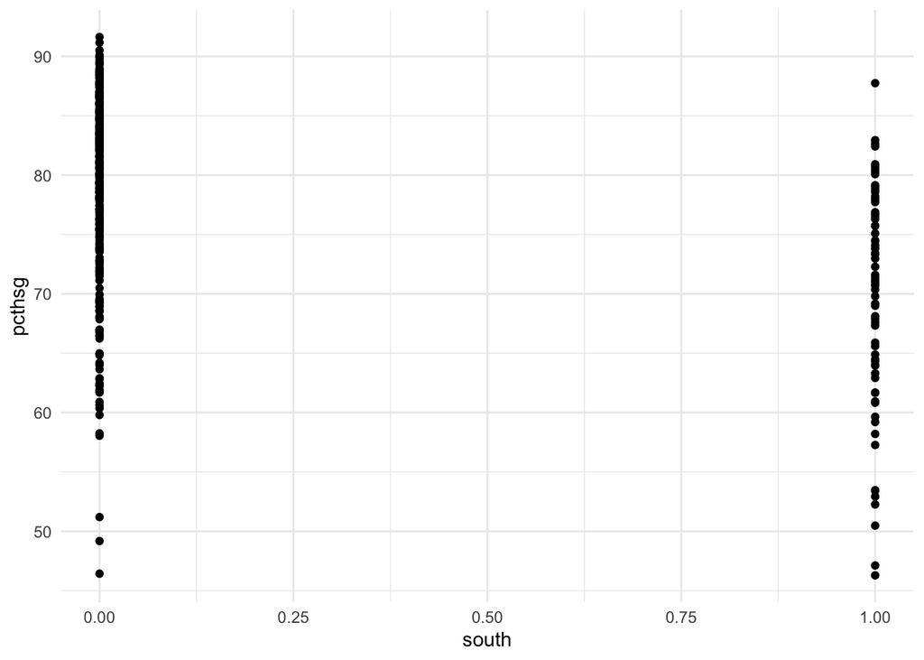

```r
ggplot(data, aes(x = south, y = pcthsg)) +
  geom_point()+
  theme_minimal()
```

In the second model, the coefficient on the South decreases by 1.11 percentage points (from 7.113 to 6.003) with the inclusion of pcthsg. This suggests that a portion of the relationship between being in the South and voter turnout is attributable to the variance in the percentage of the population with high school completion between the South and non-South states.

## Question 10

Reflecting on all of the analyses you have run, is south, in the regression from *Question 5* exogenous? Why or why not? Answer in no more than one sentence. (1 point)

**Note**

1/1

South is an endogenous variable because some of its effect in Model 1 is explained when we include pcthsg in Model 2, suggesting that south may also be correlated with other potential factors.